# Fronteras y limitaciones

Las redes neuronales, de forma más general, se pueden ver como aproximadores universales de funciones.

### Teorema de aproximación universal

> *Una red neuronal feedforward con una sola capa es suficiente para aproximar cualquier función continua*

Este teorema no nos dice nada acerca del número de unidades que debemos tener para poder aproximarnos a la función ni tampoco cómo es que se determinan los pesos para ello. Las redes neuronales más modernas son un ejemplo de esto; en 2017 se publicó un artículo donde se entrenó a una red neuronal con imágenes cuyas etiquetas eran aleatorias, lo que se encontró fue que en todos los casos, el error de entrenamiento era 0, mientras que el error en los datos de prueba aumentaba a medida que se elegían etiquetas más aleatorias.

## Limitaciones

Una arquitectura de red neuronal no es una máquina que puede dar resultados buenos con cualquier dato que se le dé. Los resultados dependen mucho del conjunto de datos de entrenamiento, por lo que es ncesario tener buenos datos para poder generalizar después de una forma adecuada, ya que la red neuronal dará predicciones de acuerdo a los tipos de datos presentados en el entrenamiento, además de la cantidad de cada tipo de dato

### Incertidumbre

Tenemos dos tipos de incertidumbres en los modelos de Deep Learning:

- Incertidumbre aleatoria: Surge por ruido en la imagen, por ejemplo, si a un clasificador le presentamos dos de los objetos en uno, tendrá que predecir cuál de los dos es la imagen presentada.
- Incertidumbre epistémica: Surge cuando le presentamos al modelo algún dato que está fuera de nuestra distribución, pero el modelo sigue dando una salida que está dentro de la distribución, generando datos erróneos.

### Ejemplos adversariales

Consiste en presentarle a nuestro modelo un ejemplo, el cual clasifica correctamente y añadir algún tipo de ruido, de forma que el resultado es muy similar al ejemplo original, pero debido al ruido agregado, el modelo se equivoca. Esto viene desde el algoritmo de gradiente descendiente, ya que puede que algún peso de alguna capa intermedia tenga mucha importancia.

Algunas limitaciones de las redes neuronales son:

- Requieren una gran cantidad de datos.
- Computacionalmente costosas de entrenar y desplegar.
- Fácilmente se equivocan con ejemplos adversariales.
- Sujetas a prejuicios de los datos.
- Complicaciones para codificar los datos.
- Complejas de optimizar.
- Usualmente requieren experiencia para diseñarlas.

## Codificación: Grafos

Actualmente se está codificando los datos en grafos. La idea es similar a las de redes convolucionales, donde tenemos una red que extrae características de la entrada y posteriormente va a una red feedforward. Las redes que realizan esto son **Graph Convolutional Networks (GCN)**, en estas redes se representan los datos como nodos conectados. En este caso se usa un kernel de características que pasa por los nodos del grafo.

Estas redes neuronales pueden extenderse para representar nubes de puntos, o elementos tridimensionales ya que los grafos preservan las relaciones que hay entre nodos.

## ML automatizado

Trata de automatizar el diseño de redes neuronales. En este tipo de arquitecturas tenemos una red neuronal denominada **controlador** y una **red hija**. El controlador propone una arquitectura de red, la cual es entrenada y se obtiene el desempeño para una tarea en específico; luego el resultado se retroalimenta al controlador y se optimizan las propuestas de red del controlador.

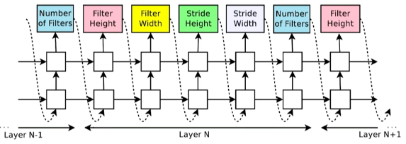